# Predictive Model for Customer Churn: A Case Study in Banking

### Objective

To develop a model/method for identifying customers who are likely to exit

### Background:

Bank customer churn, also known as customer attrition, refers to the phenomenon where customers stop doing business with a bank or switch to another bank. Churn is a critical metric for banks as it directly impacts their customer base and revenue. The dataset represents bank customer information for churn analysis. Each row in the dataset corresponds to a specific customer and contains several features or attributes that describe them.

While we have worked with BLR, Naive Bayes, and SVM in earlier case study, we will be using tree methods in this one.

### Import Libraries

```python
import pandas as pd
import numpy as np
import matplotlib.pyplot as plt
#Classification Report
from sklearn.metrics import classification_report
#Train & Test Split
from sklearn.model_selection import train_test_split
#Decision Tree
from sklearn.tree import DecisionTreeClassifier, DecisionTreeRegressor, plot_tree
#ROC
from sklearn.metrics import roc_curve, roc_auc_score
#Random Forest
from sklearn.ensemble import RandomForestClassifier
```

### Import Data

```python
data = pd.read_csv('C:/Users/SANKHYA/Downloads/Bank Churn.csv')
data.head()
```

|  | RowNumber | CustomerId | Surname | CreditScore | Geography | Gender | Age | Tenure | Balance | NumOfProducts | HasCrCard | IsActiveMember | EstimatedSalary | Exited |
| --- | --- | --- | --- | --- | --- | --- | --- | --- | --- | --- | --- | --- | --- | --- |
| 0 | 1 | 15634602 | Hargrave | 619 | France | Female | 42 | 2 | 0.00 | 1 | 1 | 1 | 101348.88 | 1 |
| 1 | 2 | 15647311 | Hill | 608 | Spain | Female | 41 | 1 | 83807.86 | 1 | 0 | 1 | 112542.58 | 0 |
| 2 | 3 | 15619304 | Onio | 502 | France | Female | 42 | 8 | 159660.80 | 3 | 1 | 0 | 113931.57 | 1 |
| 3 | 4 | 15701354 | Boni | 699 | France | Female | 39 | 1 | 0.00 | 2 | 0 | 0 | 93826.63 | 0 |
| 4 | 5 | 15737888 | Mitchell | 850 | Spain | Female | 43 | 2 | 125510.82 | 1 | 1 | 1 | 79084.10 | 0 |

### Data Description

|  | Field | Description |
| --- | --- | --- |
| 0 | CustomerId | Customer identifiers |
| 1 | Surname | Surname of Customer |
| 2 | CreditScore | Creditworthiness score of customers |
| 3 | Geography | Country name |
| 4 | Gender | Gender of customer |
| 5 | Age | Age of customer |
| 6 | Tenure | Duration of customer engagement or membership |
| 7 | Balance | Amount of funds held in customer accounts |
| 8 | NumOfProducts | Number of products or services owned by customers |
| 9 | HasCrCard | Whether customers possess a credit card or not |
| 10 | IsActiveMember | Whether customers are active member of loyalty program |
| 11 | EstimatedSalary | The approximate salary of customers |
| 12 | Exited | Whether customers have churned or exited the service |

### Converting data types (Required for modelling)

```python
data[['HasCrCard','IsActiveMember','Geography', 'Gender']] = data[['HasCrCard','IsActiveMember','Geography','Gender']].astype('category')
data.info()
```

```
<class 'pandas.core.frame.DataFrame'>
RangeIndex: 10000 entries, 0 to 9999
Data columns (total 14 columns):
 #   Column           Non-Null Count  Dtype
---  ------           --------------  -----
 0   RowNumber        10000 non-null  int64
 1   CustomerId       10000 non-null  int64
 2   Surname          10000 non-null  object
 3   CreditScore      10000 non-null  int64
 4   Geography        10000 non-null  category
 5   Gender           10000 non-null  category
 6   Age              10000 non-null  int64
 7   Tenure           10000 non-null  int64
 8   Balance          10000 non-null  float64
 9   NumOfProducts    10000 non-null  int64
 10  HasCrCard        10000 non-null  category
 11  IsActiveMember   10000 non-null  category
 12  EstimatedSalary  10000 non-null  float64
 13  Exited           10000 non-null  int64
dtypes: category(4), float64(2), int64(7), object(1)
memory usage: 820.9+ KB
```

### Splitting Data into Train and Test data sets

```python
# Define the features and target variable
x_variables = ['CreditScore', 'Geography', 'Gender', 'Age', 'Tenure', 'Balance',
               'NumOfProducts', 'HasCrCard', 'IsActiveMember', 'EstimatedSalary']
X = data[x_variables]
y = data['Exited']

# Convert categorical variables into dummy variables
X_encoded = pd.get_dummies(X, columns=['Geography', 'Gender', 'HasCrCard', 'IsActiveMember'], drop_first=True)

# Split the data into training and testing sets
X_train, X_test, y_train, y_test = train_test_split(X_encoded, y, test_size=0.3, random_state=42)
```

### Estimating the attrition rate

```python
counts = data['Exited'].value_counts().reset_index()
counts.columns = ['Exited', 'Freq']
counts['Percent'] = counts['Freq'] / counts['Freq'].sum()

print(counts)
```

```
   Exited  Freq  Percent
0       0  7963   0.7963
1       1  2037   0.2037
```

## Model 1. Decision Tree

### Building Model

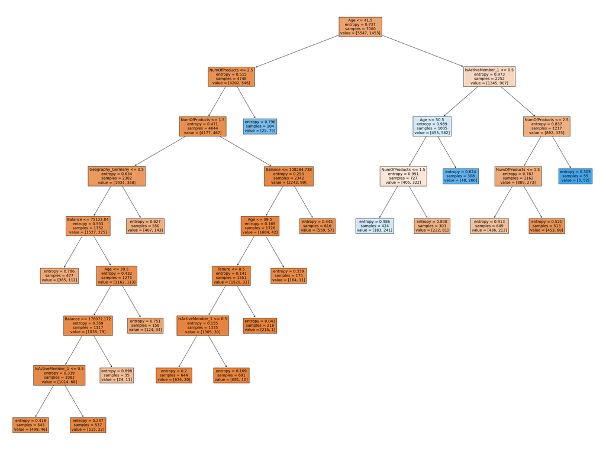

```python
dtcl = DecisionTreeClassifier(criterion='entropy', min_samples_split= int(len(X_train)*.10))
dtcl.fit(X_train, y_train)
plt.figure(figsize = (40,30))
plot_tree(dtcl, filled = True, feature_names = list(X_encoded.columns))
plt.show()
```

### Multicollinearity

Multicollinearity, which is the high correlation between predictor variables, is generally not a concern for tree-based methods like decision trees, random forests, and gradient boosting machines. These methods are inherently able to handle multicollinearity because they select variables based on how well they split the data at each node, rather than relying on the strength or direction of the relationship between predictors.

In contrast, linear regression, logistic regression, and other linear models can be greatly affected by multicollinearity, as they depend on the inversion of matrices that can become unstable when predictors are highly correlated.

### ROC Curve and AUC for Test Data

```python
#Calculating Predictions for the model
y_pred = dtcl.predict(X_test)
y_pred_probs = dtcl.predict_proba(X_test)
```

```python
#Area Under ROC Curve
auc = roc_auc_score(y_test, y_pred_probs[:,1])
print('AUC: %.3f' % auc)
```

```
AUC: 0.832
```

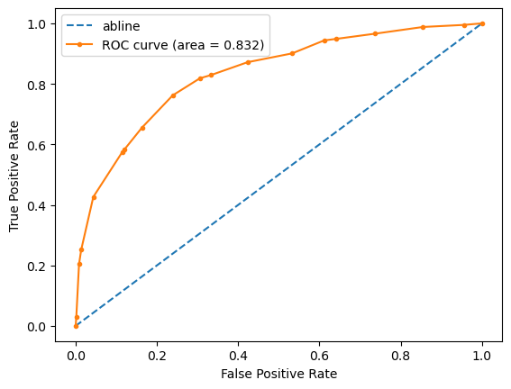

```python
#ROC Curve
DTfpr, DTtpr, thresholds = roc_curve(y_test, y_pred_probs[:,1])

abline_probs = [0 for _ in range(len(y_test))]
abline_auc = roc_auc_score(y_test, abline_probs)
abline_fpr, abline_tpr, _ = roc_curve(y_test, abline_probs)

plt.plot(abline_fpr, abline_tpr, linestyle='--', label='abline')
plt.plot(DTfpr, DTtpr, marker='.', label='ROC curve (area = %.3f)' % auc)
plt.xlabel('False Positive Rate');plt.ylabel('True Positive Rate')
plt.legend();
plt.show()
```

### Generate Classification Report

```python
print(classification_report(y_test,y_pred))
```

```
              precision    recall  f1-score   support

           0       0.87      0.96      0.91      2416
           1       0.70      0.43      0.53       584

    accuracy                           0.85      3000
   macro avg       0.79      0.69      0.72      3000
weighted avg       0.84      0.85      0.84      3000
```

#### Comment :

The overall model accuracy is 85%. The area under ROC curve is 83.2

## Model 2. Random Forest

### Building Model

```python
rf = RandomForestClassifier(random_state=999, n_estimators=100, oob_score=True, max_features='sqrt')
rf.fit(X_train, y_train)
```

```
RandomForestClassifier(oob_score=True, random_state=999)
```

```python
rf.oob_score_
```

```
0.8578571428571429
```

### Variable Importance

```python
#Feature importance
rf.feature_importances_
```

```
array([0.14428493, 0.23946382, 0.08136962, 0.14157388, 0.12746573,
       0.14664391, 0.02562787, 0.01426298, 0.01850706, 0.019517  ,
       0.0412832 ])
```

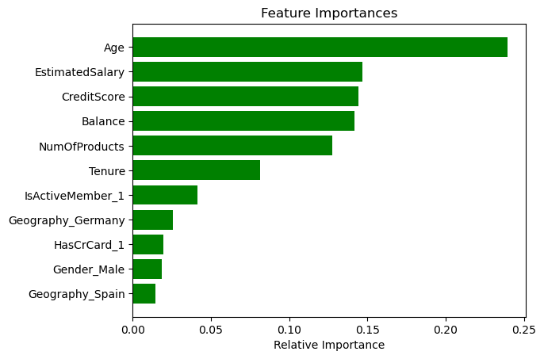

```python
#Importance Matrix
features = list(X_encoded.columns)
importances = rf.feature_importances_
indices = np.argsort(importances)


plt.title('Feature Importances')
plt.barh(range(len(indices)), importances[indices], color='g', align='center')
plt.yticks(range(len(indices)), [features[i] for i in indices])
plt.xlabel('Relative Importance')
plt.show()
```

### ROC Curve and AUC for Test Data

```python
#Calculating Predictions for the model
y_pred = rf.predict(X_test)
y_pred_probs = rf.predict_proba(X_test)
```

```python
#Area Under ROC Curve
auc = roc_auc_score(y_test, y_pred_probs[:,1])
print('AUC: %.3f' % auc)
```

```
AUC: 0.854
```

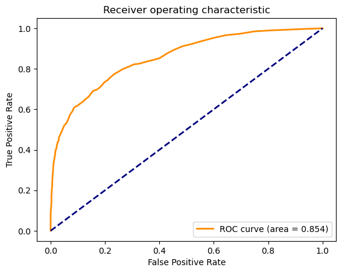

```python
#ROC Curve
RFfpr, RFtpr, thresholds = roc_curve(y_test, y_pred_probs[:,1])

# plot the roc curve for the model
plt.figure()
lw = 2
plt.plot(RFfpr, RFtpr, color='darkorange',lw=lw, label='ROC curve (area = %.3f)' % auc)
plt.plot([0, 1], [0, 1], color='navy', lw=lw, linestyle='--')
plt.axis('tight')
plt.xlabel('False Positive Rate');plt.ylabel('True Positive Rate')
plt.title('Receiver operating characteristic')
plt.legend(loc="lower right")
plt.show()
```

### Generate Classification Report

```python
print(classification_report(y_test,y_pred))
```

```
              precision    recall  f1-score   support

           0       0.88      0.97      0.92      2416
           1       0.78      0.46      0.58       584

    accuracy                           0.87      3000
   macro avg       0.83      0.72      0.75      3000
weighted avg       0.86      0.87      0.86      3000
```

#### Comment:

The overall model accuracy is 87%. The area under ROC curve is 85.4

### Conclusion:

The Random forest method gives higher AUC for test data when compared with Decision tree. Recall values can be improved and balanced by changing the threshold for prediction